# Основы интерфейса взаимодействия с системой Unix на уровне командной строки

Лабораторная работа №6

Мухина Ксения Николаевна

1032253531@pfur.ru

2026-03-21

# Информация

## Докладчик

- Мухина Ксения Николаевна
- студент 1 курса, бакалавриат
- компьютерные и информационные науки
- Российский университет дружбы народов им. П. Лумумбы
- 1032253531@rudn.ru
- https://github.com/knmuhina/

# Вводная часть

## Актуальность

- Умение работать с командной строкой необходимо для работы в системах без полноценной графической оболочки.

## Объект и предмет исследования

- командная строка и её команды

## Цели и задачи

- Приобрести практические навыки взаимодействия с системой посредством командной строки
- определение домашнего каталога выполняющего
- выполнение заданий относительно данного каталога:
  - перемещение по файловой системе
  - создание и удаление каталогов
- работа с командой man
- работа с командой history

# Теоретическое введение

## Командная строка

- Командная строка позволяет взаиамодействовать с ОС через ввод текстовых команд
- Основные команды: cd, ls, mkdir, rm/rmdir, man

# Выполнение работы

## Работа с командами pwd, cd и ls

- Перед началом работы определяется полное имя домашнего каталога посредством pwd
- Далее проводится работа с различными опциями команд cd и ls

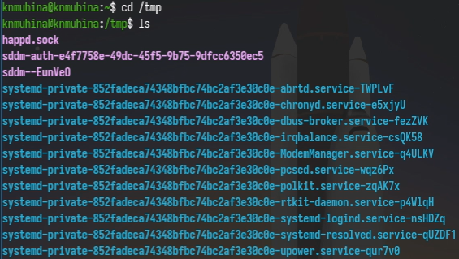

Пример работы с командами.

## Работа с командами mkdir и rmdir

- Проводится работа с различными опциями команд mkdir и rmdir.

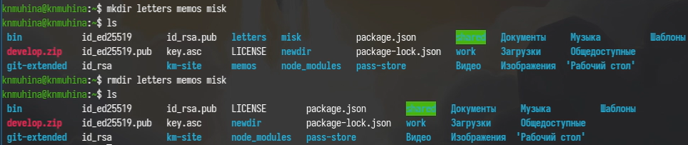

Пример работы с командами.

## Работа с командами man и history

- Проводится работа с различными опциями команд man и history

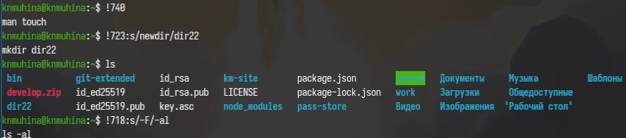

Пример работы с командами.

# Результаты

## Результаты выполнения работы

- Были навыки взаимодействия с системой посредством командной строки.

## Контрольные вопросы

- Командная строка - способ взаиамодействия с ОС через ввод текстовых команд с клавиатуры
- Символы экранирования - специальные символы, которые помогают вставлять служебные символы в текст или задавать специальные действия
- Относительный путь к файлу - путь, который указывается от текущей рабочей папки, а не от корня диска
- Абсолютный путь - полный путь от корня файловой системы
- Клавиша Tab служит для автоматического дополнения вводимых команд